# STAT 240 Discussion 7

## Members Present

**Nico Salm**, Dheeraj Pasikanti, Jinming Liu, Michelle Kim

## Questions

### 1

For each scenario, explain why the random variable does *not* have a binomial distribution.

1. A bucket contains 10 colored tokens with five that are red and five that are blue. Four tokens are drawn at random from the bucket one at a time, but without replacing the tokens drawn. $X_1$ is the number of red tokens selected.
- The probabilities change with each draw, violating the requirement of a constant probability of success.
- Trials are not independent since each draw affects the composition of the remaining tokens.
2. A fair coin is tossed repeatedly until the tenth head is tossed. $X_2$ is the number of tails tossed prior to the tenth head.
- There is no fixed number of trials which violates the binomial criterion of a set number of experiments.
3. Four buckets each contain a total of five tokens each, some red and some blue. The number of red tokens in the buckets are 1, 2, 3, and 4 with blue tokens making up the remainder. One token is drawn at random from each bucket. $X_3$ is the total number of red tokens drawn.
- The probability of success isn’t constant but varies by the bucket, violating the binomal requirement of a consistent success probability across all trials.

### 2

Let $X \sim \operatorname{Binomial}(25,0.4)$.

#### A

Calculate and report the mean $\mu=\mathrm{E}(X)$ and the standad deviation $\sigma=\sqrt{\operatorname{Var}(X)}$

```r
Binomial <- function(n, p) {
  if (n <= 0 | p < 0 | p > 1) {
    stop("invalid input: n must be positive, and p must be between 0 and 1.")
  }

  # calculate mean and variance
  mean = n * p
  var = n * p * (1 - p)

  # stdev
  stdev = sqrt(var)

  results = c(mean = mean, variance = var, std_dev = stdev)
}

stats = Binomial(25,0.4)
stats
```

```
##     mean variance  std_dev
## 10.00000  6.00000  2.44949
```

mean = 10, std_dev = 2.45

#### B

Calculate $\text{P}(X \geq 14)$

```r
n = 25
p = 0.4

# pbinom gives probability X ≤ p
# want: P(X ≥ 14), so calculate complement, 1 - P(X < 14)
# this is the same as 1 - P(X ≤ 13) since binomial dist is discrete

prob = 1 - pbinom(13, size = n, prob = p)

print(prob)
```

```
## [1] 0.07780106
```

7.8%

#### C

Create a graph of the $\operatorname{Binomial}(25,0.4)$ distribution. Color the segments for $x=14,15,...,25$ red and use gray for the rest. Plot using `theme_minimal()`.

You may edit the code in this block which does something similar for a different problem. Note the use of `geom_binom_density()` with different values of `a` AND `b`.

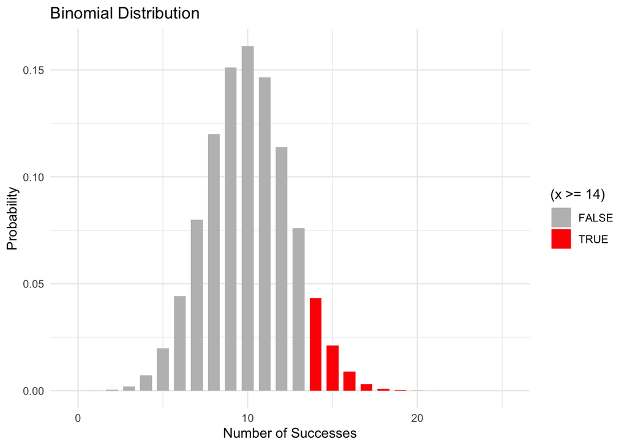

```r
# parameters
n <- 25
p <- 0.4

# Create a dataframe containing the outcomes and their probabilities
data <- data.frame(x = 0:n)
data$probability <- dbinom(data$x, size = n, prob = p)

# Create the base plot
p <- ggplot(data, aes(x = x, y = probability)) +
  geom_bar(stat = "identity", aes(fill = (x >= 14)), width = 0.7) +
  scale_fill_manual(values = c("TRUE" = "red", "FALSE" = "gray")) +
  labs(title = "Binomial Distribution", x = "Number of Successes", y = "Probability") +
  theme_minimal()

p
```

### 3

Create a data frame with columns `n`, `p`, `x`, `mu`, and `prob` where:

- `n` varies from 2 to 100 by twos (so each `n` value is even);
- `p` equals 0.5;
- `x` is $n/2$;
- `mu` is the mean of the distribution;
- `prob` is $P(X = x)$

Show the first few rows using `head()`.

```r
df = tibble(n = seq(2, 100, by = 2)) %>%
  mutate(
    p = 0.5,
    x = n / 2,
    mu = n * p,
    prob = dbinom(x, n, p)
  )
head(df)
```

```
## # A tibble: 6 × 5
##       n     p     x    mu  prob
##   <dbl> <dbl> <dbl> <dbl> <dbl>
## 1     2   0.5     1     1 0.5
## 2     4   0.5     2     2 0.375
## 3     6   0.5     3     3 0.312
## 4     8   0.5     4     4 0.273
## 5    10   0.5     5     5 0.246
## 6    12   0.5     6     6 0.226
```

**(a)** What is the relationship between `x` and `mu`?

x is defined as n/2 and mu (mean) is defined as nxp. Since p=0.5, both x and mu are equal

**(b)** Make a line graph of `prob` versus `n`.

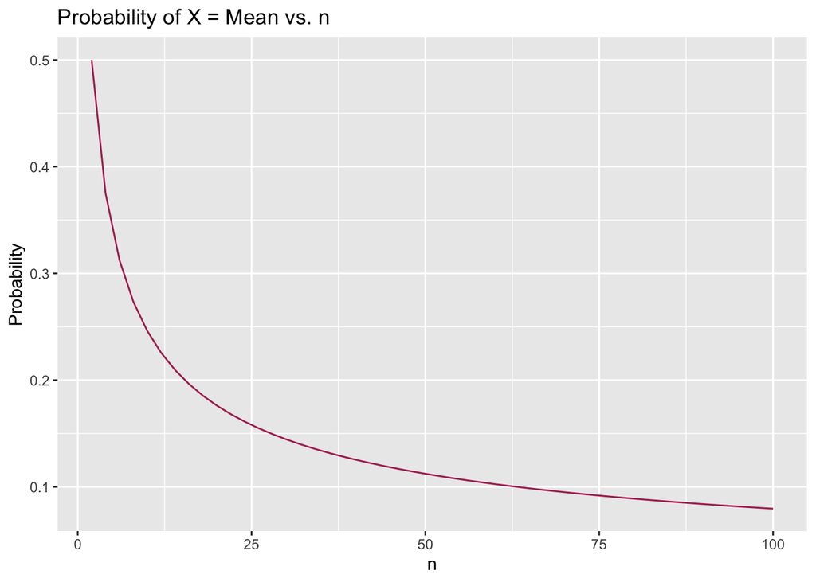

```r
p = ggplot(df, aes(x = n, y = prob)) +
  geom_line(color = "maroon") +
  labs(title = "Probability of X = Mean vs. n", x = "n", y = "Probability")
p
```

**(c)** Describe the pattern: how does the probability that a random variable is equal to the mean (when the mean is a possible value) change as $n$ increases?

- As ‘n’ increases, P(X) = mean generally decreases. As #trials increases, the distribution becomes wider, spreading the probability out over more potential outcomes, even though it also becomes more symmetric.

### 4

The central limit theorem implies that the binomial distribution converges to a normal distribution as $n$ increases. This problem will examine one aspect of the convergence, namely the right tail probability of being more than two standard deviations above the mean, $P(X > \mu + 2\sigma)$.

**(a)** What is the probability that a normal random variable with mean $\mu$ and standard deviation $\sigma$ exceeds $\mu + 2 \sigma$? Display answer rounded to four decimal places.

0.68 0.95 0.997

```r
prob = 1 - pnorm(2)
round(prob, 4)
```

```
## [1] 0.0228
```

0.0228 or 2.28%

**(b)**

Create a data frame with columns `n`, `p`, `mu`, `sigma`, `x`, and `prob` where:  
- `n` varies from 1 to 1000 by ones;  
- `p` equals 0.5;  
- `mu` is the mean of the distribution;  
- `sigma` is the standard deviation of the distribution;  
- `x` equals `mu` + 2*`sigma`;  
- `prob` is $P(X > x)$

Display the first few rows of the data frame with `head()`.

```r
df = tibble(n = 1:1000) %>%
  mutate(
    p = 0.5,
    mu = n * p,
    sigma = sqrt(n * p * (1 - p)),
    x = mu + 2 * sigma,
    prob = pbinom(x, n, p, lower.tail = FALSE)
  )
head(df)
```

```
## # A tibble: 6 × 6
##       n     p    mu sigma     x   prob
##   <int> <dbl> <dbl> <dbl> <dbl>  <dbl>
## 1     1   0.5   0.5 0.5    1.5  0
## 2     2   0.5   1   0.707  2.41 0
## 3     3   0.5   1.5 0.866  3.23 0
## 4     4   0.5   2   1      4    0
## 5     5   0.5   2.5 1.12   4.74 0.0312
## 6     6   0.5   3   1.22   5.45 0.0156
```

**(c)** Plot the right tail probabilities versus $n$. Add a red, dashed, horizontal line at the value you found in part **(a)**. Add a smooth curve which lessens the visual impact of the oscillations due to the discreteness of the binomial distribution.

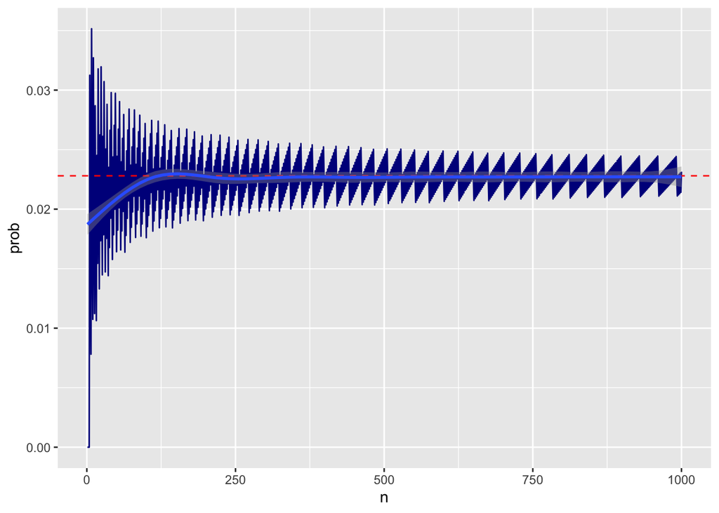

```r
ggplot(df, aes(x = n, y = prob)) +
  geom_line(color = "darkblue") +
  geom_hline(yintercept = 0.0228, linetype = "dashed", color = "red") +
  geom_smooth()
```

**(d)** Repeat parts **(b)** and **(c)** if $p = 0.005$.

```r
df = tibble(n = 1:1000) %>%
  mutate(
    p = 0.005,
    mu = n * p,
    sigma = sqrt(n * p * (1 - p)),
    x = mu + 2 * sigma,
    prob = pbinom(x, n, p, lower.tail = FALSE)
  )
head(df)
```

```
## # A tibble: 6 × 6
##       n     p    mu  sigma     x    prob
##   <int> <dbl> <dbl>  <dbl> <dbl>   <dbl>
## 1     1 0.005 0.005 0.0705 0.146 0.005
## 2     2 0.005 0.01  0.0997 0.209 0.00998
## 3     3 0.005 0.015 0.122  0.259 0.0149
## 4     4 0.005 0.02  0.141  0.302 0.0199
## 5     5 0.005 0.025 0.158  0.340 0.0248
## 6     6 0.005 0.03  0.173  0.376 0.0296
```

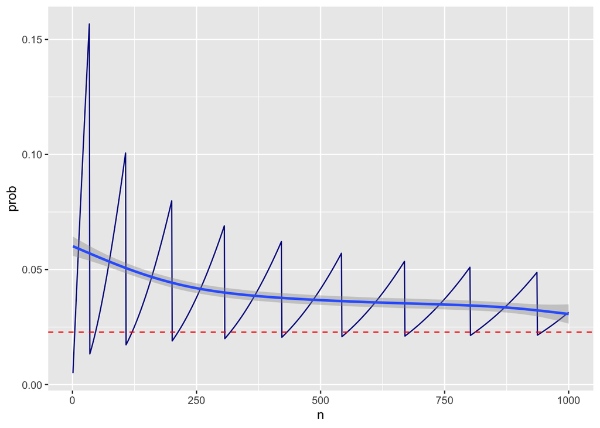

```r
ggplot(df, aes(x = n, y = prob)) +
  geom_line(color = "darkblue") +
  geom_hline(yintercept = 0.0228, linetype = "dashed", color = "red") +
  geom_smooth()
```

**(e)**

Ignoring the oscillations, how do the patterns of the two smooth curves in the graphs differ from one another, especially when $n$ is large?

As we choose p further and further from 0.5 we see less accurate data as is it much more spread out.

### 5

Repeat problems 4B and 4C if $p=0.005$

See above 4D.

### 6

Draw graphs of the binomial distributions for $n=500$ and $p = 0.5$ and $p = 0.005$, scaled so that the x axis is restricted to where the probabilities are relatively large. (One graph for each of the two $p$’s.) Overlay each plot with a red normal density with a mean and standard deviation that matches the mean and standard deviation of the corresponding binomial distribution. (Use functions in *gprob.R* for these graphs and set `scale=TRUE`.)

Compare the skewness of the distributions. Comment on how this might help explain the differences in the right tail probabilities from Problem 3.

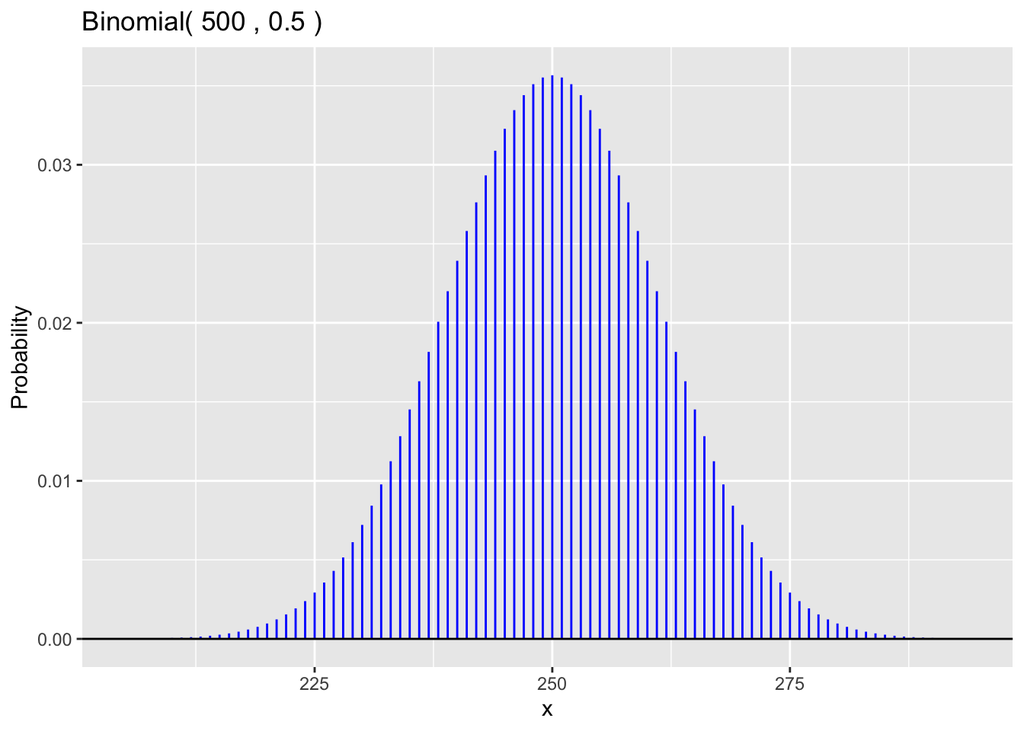

```r
# Set parameters
n <- 500
p1 <- 0.5
p2 <- 0.005

# mean and standard deviation for the binomial distributions
mean1 <- n * p1
std_dev1 <- sqrt(n * p1 * (1 - p1))
mean2 <- n * p2
std_dev2 <- sqrt(n * p2 * (1 - p2))

# generate plots
binom_plot1 <- gbinom(n, p1, scale = TRUE)
norm_overlay1 <- gnorm(mean1, std_dev1, color = "red")
binom_plot1
```

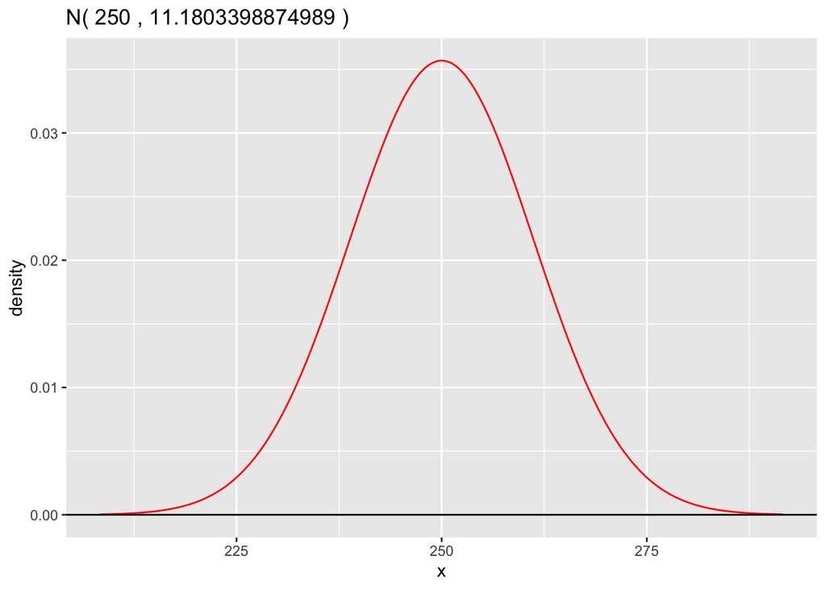

```r
norm_overlay1
```

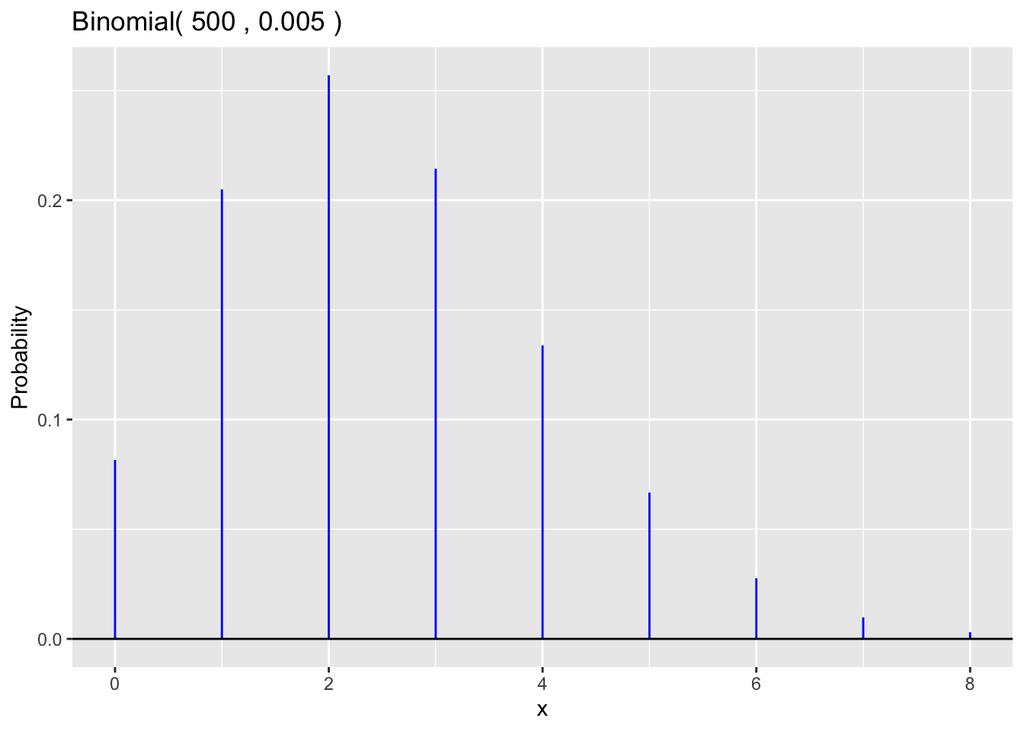

```r
# for the second plot with p = 0.005
binom_plot2 <- gbinom(n, p2, scale = TRUE)
norm_overlay2 <- gnorm(mean2, std_dev2, color = "red")
binom_plot2
```

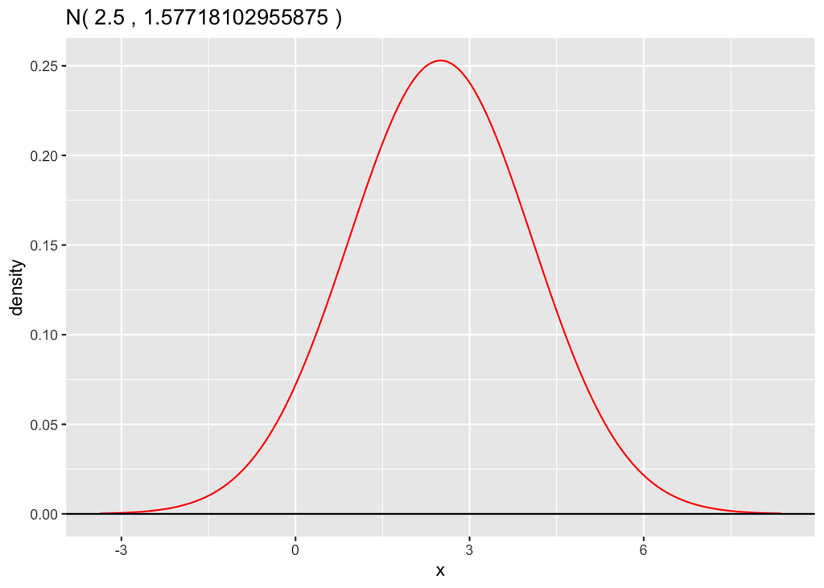

```r
norm_overlay2
```

NOTE: Since gbinom and gnorm return ggplot objects and not layers, we cannot layer them together.

The binomial distribution with p=0.5 is symmetric, yielding balanced tails, while p=0.005 introduces positive skew, emphasizing a heavier right tail. This explains the higher probabilities of extreme values in the right tail for p=0.005, as observed in Problem 3.